# Re-creating MacLeod’s CVA Example

## Libraries

```r
library(tidyverse)
library(ggthemes)
library(cowplot)
library(broom)
library(magrittr)
library(ggsci)
library(rlang)
```

# Preliminaries

First we’ll change a few of the defaults so we have consistent scatter plots with easily distinguishable symbol shapes and colors.

```r
update_geom_defaults("point", list(size=2, stroke=1))
scale_colour_discrete <- function(...) scale_color_d3(palette="category10")
scale_shape_discrete <- function(...) scale_shape_few()
```

# MacLeod’s illustrative example of CVA

Norman MacLeod (Natural History Museum, London) has published a very nice series of tutorials/essays in the Paleontological Association Newsletter that cover key methods in multivariate statistics (see [PalaeoMath](https://www.palass.org/publications/newsletter/palaeomath-101). MacLeod’s article on [Canonical Variates Analysis](https://www.palass.org/sites/default/files/media/palaeomath_101/article_11/article_11.pdf) does a nice job of explaining how CVA can be implemented as a two-step PCA. However, there are some errors in several of the figures. This notebook corrects these errors, and illustrates how to generate the correct figures.

# Examplar data set

MacLeod uses famous Anderson (Fisher) iris data set to illustrate CVA. His example data set is composed of the first twenty-five specimens from each species.

```r
first25 <- iris %>%
  group_by(Species) %>%
  group_map(~head(., 25)) %>% # useful dplyr fxn, read the docs!
  ungroup
```

MacLeod states “in our geometric example analysis we’ll reduce the Table 1 data to just two variables: petal width and petal length” and all of his figures using these two variables as the axes of the untransformed data. However, if we plot these data it’s clear that **the figures he illustrates are based on sepal width and length NOT petal width and length***. Note that his figures also clearly show the data has been mean centered so we’ll do that as well.

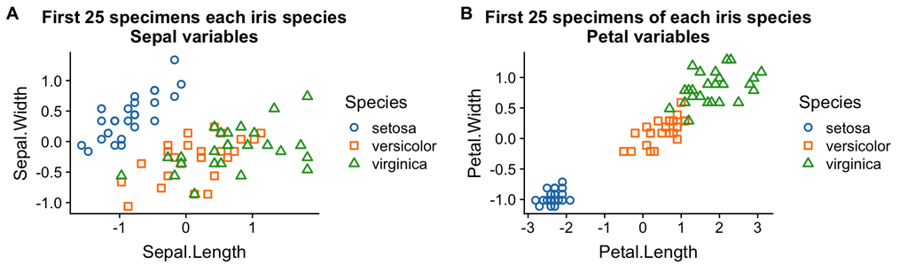

```r
iris.sepals <-
  first25 %>%
  dplyr::select(Species, Sepal.Length, Sepal.Width) %>%
  mutate_if(is.numeric, function(x) {x - mean(x)})

iris.petals <-
  first25 %>%
  dplyr::select(Species, Petal.Length, Petal.Width) %>%
  mutate_if(is.numeric, function(x) {x - mean(x)})

plot_sepals <-
  iris.sepals %>%
  ggplot(aes(x = Sepal.Length, y = Sepal.Width, shape = Species, color = Species)) +
  geom_point() +
  labs(title = "First 25 specimens each iris species\nSepal variables")

plot_petals <-
  iris.petals %>%
  ggplot(aes(x = Petal.Length, y = Petal.Width, shape = Species, color = Species)) +
  geom_point() +
  labs(title = "First 25 specimens of each iris species\nPetal variables")

plot_grid(plot_sepals, plot_petals, labels="AUTO")
```

Compare the figures above to MacLeod’s figure 2A. MacLeod’s analyses are clearly based on the Sepal variables. In the following analyses that’s what we’ll use so our results can be compared to his.

# Plotting functions

We’ll be producing lots of plots of the same type below. To cut down on boiler plate I’ve written some “wrapper functions” to automate specifying some of the parameters of geoms. Note that the code below uses “Non-Standard Evaluation” (NSE) so that we can pass naked variable names to our functions in the same way that ggplot and dplyr do. NSE is a type of “metaprogramming” (writing programs with programs). For more about NSE see [Programming with dplyr](https://dplyr.tidyverse.org/articles/programming.html) and [Wickham’s Advanced R](http://adv-r.had.co.nz/Computing-on-the-language.html)).

```r
draw_grouped_points <- function(data, x, y, group, ...) {
  x <- enquo(x)
  y <- enquo(y)
  group <- enquo(group)
  geom_point(data = data,
             aes(x = !! x,
                 y = !! y,
                 color = !! group,
                 shape = !! group), ...)
}

draw_axes <- function(data, x, y, ...) {
  x <- enquo(x)
  y <- enquo(y)
  geom_segment(data = data,
               aes(x =   - !! x,
                   xend =  !! x,
                   y =   - !! y,
                   yend =  !! y), ...)
}

label_axes <- function(data, x, y, label, ...) {
  x <- enquo(x)
  y <- enquo(y)
  label <- enquo(label)
  geom_text(data = data,
            aes(x = !! x,
                y = !! y,
                label = !! label),
            ...)

}

points_and_axes <- function(data, axes.data, x, y, group, label, ...) {
  x <- enquo(x)
  y <- enquo(y)
  group <- enquo(group)
  label <- enquo(label)
  ggplot() +
    draw_grouped_points(data, !! x, !! y, !! group, ...) +
    draw_axes(axes.data, !! x, !! y) +
    label_axes(axes.data, !! x, !! y, !! label)
}
```

# MacLeod’s analysis

For his example, Macload analyzed the first 25 specimens of each Iris species. His figures say Petal Length and Petal Width, but this is clearly a mistake and the figures are instead based on Sepal Length and Width.

Let’s create a data frame and corresponding numerical matrix with the subset of the data Macleod analyzed.

```r
iris.sepals <-
  iris %>%
  dplyr::select(-Petal.Length, -Petal.Width) %>%
  group_by(Species) %>%
  group_map(~head(., 25)) %>%
  ungroup %>%
  mutate_if(is.numeric, scale, center=TRUE, scale=FALSE)
```

## Original data

First let’s create plot of the data in the space of the original variables. Since some of the points overlap we’ll add a fixed amount of jitter (so the points match from figure to figure).

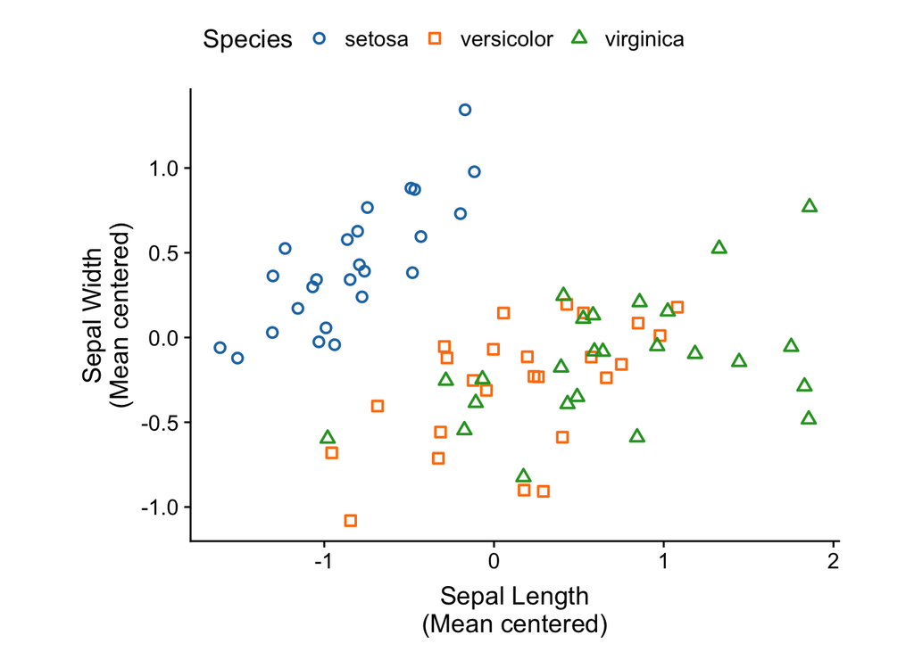

```r
fixed.jitter <- position_jitter(height=0.05, width=0.05, seed = 20190328)
plot.theme <- theme(legend.position = "top")

plot_orig <-
  ggplot() +
  draw_grouped_points(iris.sepals, Sepal.Length, Sepal.Width,
                      group = Species, position = fixed.jitter) +
  labs(x = "Sepal Length\n(Mean centered)",
       y = "Sepal Width\n(Mean centered)") +
  coord_fixed() +
  plot.theme

plot_orig
```

## Preliminary calculations

```r
nobs <- nrow(iris.sepals)
ngroups <- nlevels(iris.sepals$Species)

# calculate deviations around grand mean
tot.deviates <-
  iris.sepals %>%
  dplyr::select(-Species) %>%
  mutate_all(~(. - mean(.))) %>%
  as.matrix

# Total SSQ and covariance matrix
ssq.tot <- t(tot.deviates) %*% tot.deviates
cov.tot <- ssq.tot/nobs

# calculate deviations around group means
win.deviates <-
  iris.sepals %>%
  group_by(Species) %>%
  mutate_at(vars(-group_cols()), ~(. - mean(.))) %>%
  ungroup %>%
  dplyr::select(-Species) %>%
  as.matrix

# Within group SSQ and covariance
ssq.win <- t(win.deviates) %*% win.deviates
cov.win <- ssq.win/(nobs - ngroups)

# Eigenvectors/values of within group covariance
win.eigen <- eigen(cov.win)

# Between group deviates
btw.deviates <-
  iris.sepals %>%
  group_by(Species) %>%
  summarize_all(mean) %>%
  dplyr::select(-Species) %>%
  mutate_at(vars(-group_cols()), ~(. - mean(.))) %>%
  as.matrix

# Between group SSQ and covariance
ssq.btw <- ngroups * t(btw.deviates) %*% btw.deviates
cov.btw <- ssq.btw/(ngroups-1)

# a matrix representation of the original data (minus the Species column)
# we'll be useful for various calculations
iris.sepals.mtx <-
  iris.sepals %>%
  dplyr::select(-Species) %>% # drop Species column
  as.matrix  # cast to matrix for calculations
```

Now let’s draw those eigenvectors in the space of the original variables.

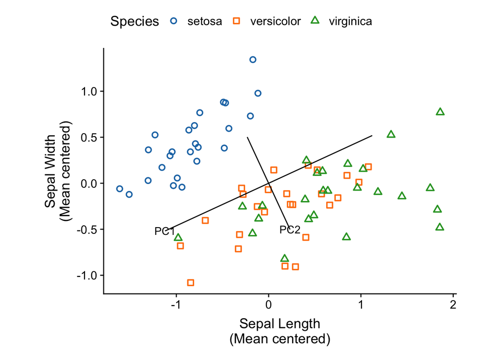

```r
win.PCs <-
  win.eigen$vectors %*% (2 * diag(sqrt(win.eigen$values))) %>%
  set_colnames(c("PC1", "PC2")) %>%
  set_rownames(c("Sepal.Length", "Sepal.Width")) %>%
  t() %>%
  as_tibble(rownames = "PC")

plot_win.PC.in.orig <-
  points_and_axes(iris.sepals, win.PCs,
                  Sepal.Length, Sepal.Width, Species, PC,
                  position = fixed.jitter) +
  labs(x = "Sepal Length\n(Mean centered)",
       y = "Sepal Width\n(Mean centered)") +
  coord_fixed() +
  plot.theme

plot_win.PC.in.orig
```

# Within group PCs

Now let’s draw the observations projected into the space of the within group PCs. First calculate the PC scores:

```r
win.PC.scores.mtx <-
  iris.sepals.mtx %*% win.eigen$vectors %>%
  set_colnames(str_c("PC", 1:ncol(iris.sepals.mtx)))

win.PC.scores <-
  as.data.frame(win.PC.scores.mtx) %>%
  mutate(Species = iris.sepals$Species)
```

And then plot the scores:

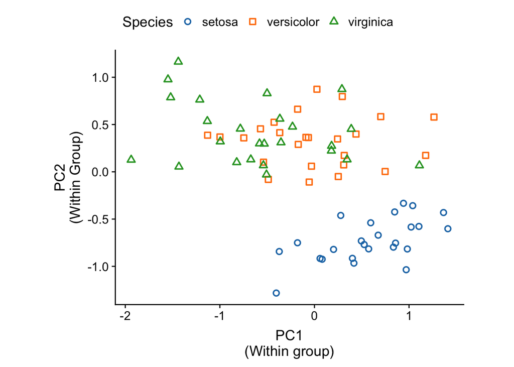

```r
plot_win.PC <-
  ggplot() +
  draw_grouped_points(win.PC.scores, PC1, PC2, Species, position = fixed.jitter) +
  labs(x = "PC1\n(Within group)", y = "PC2\n(Within Group)") +
  coord_fixed() +
  plot.theme

plot_win.PC
```

We then scale the within-group PCs the reciprocal of the square root of their eigenvalues:

```r
win.scaling <- diag(1/sqrt(win.eigen$values))

scaled.win.PC.scores.mtx <-
  win.PC.scores.mtx %*% win.scaling %>%
  set_colnames(str_c("scaledPC", 1:ncol(iris.sepals.mtx)))

scaled.win.PC.scores <-
  as.data.frame(scaled.win.PC.scores.mtx) %>%
  mutate(Species = iris.sepals$Species)
```

Now create a plot of the scaled within group PCs and scores:

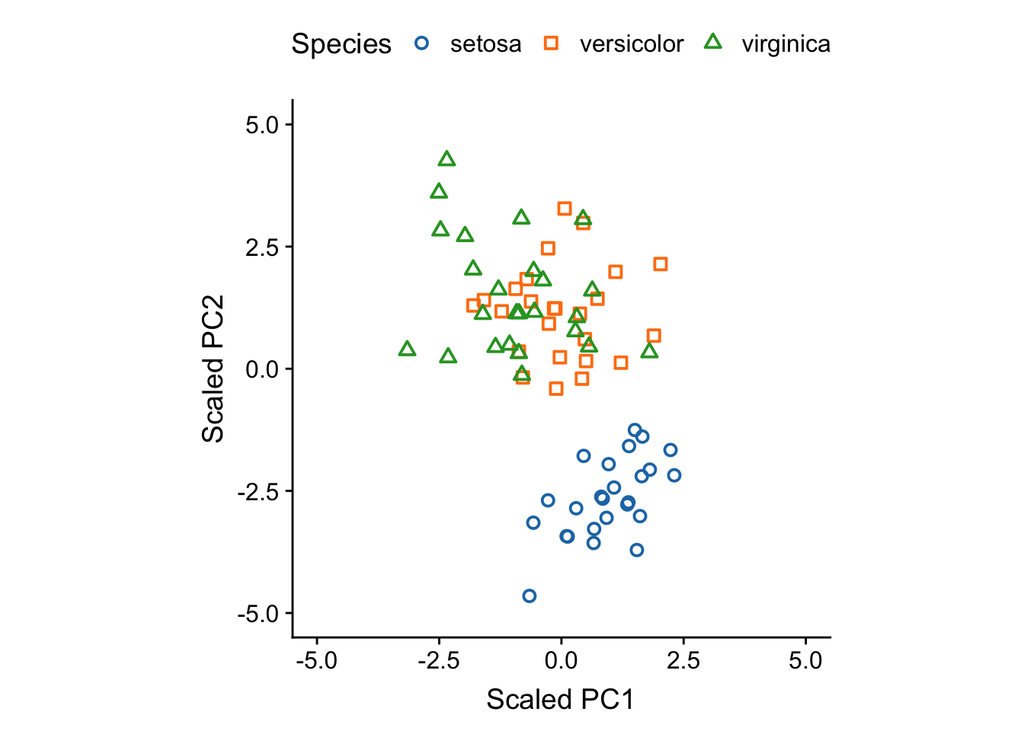

```r
plot_scaled.win.PC <-
  ggplot() +
  draw_grouped_points(scaled.win.PC.scores, scaledPC1, scaledPC2, Species,
                      position = fixed.jitter) +
  labs(x = "Scaled PC1", y = "Scaled PC2") +
  xlim(-5,5) + ylim(-5,5) +
  coord_fixed() +
  plot.theme

plot_scaled.win.PC
```

# Group means and group PC

Calculate the group means in the space of scaled PCs

```r
scaled.group.means <-
  scaled.win.PC.scores %>%
  group_by(Species) %>%
  summarize(scaledPC1 = mean(scaledPC1), scaledPC2 = mean(scaledPC2))
```

Calculate the group sum-of-squares and cross-products (SSQCP) matrix, and its corresponding eigenvectors and values.

```r
group.ssqcp <- cov(scaled.group.means %>% select(-Species)) * (ngroups - 1)
group.eigen <- eigen(group.ssqcp)
```

Now plot the group means and their eigenvectors:

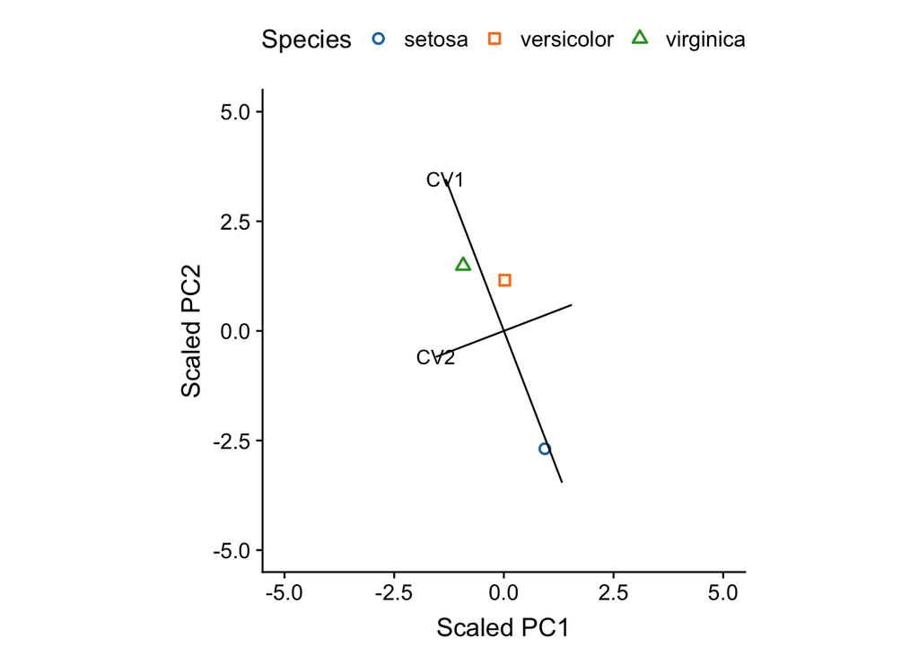

```r
group.PCs <-
  group.eigen$vectors %*% (6 * diag(sqrt(win.eigen$values))) %>%
  set_colnames(c("CV1", "CV2")) %>%
  set_rownames(c("scaledPC1", "scaledPC2")) %>%
  t() %>%
  as_tibble(rownames = "CV")

plot_group.mean.PCs <-
  points_and_axes(scaled.group.means, group.PCs, scaledPC1, scaledPC2, Species, CV,
                  position = fixed.jitter) +
  labs(x = "Scaled PC1", y = "Scaled PC2") +
  xlim(-5,5) + ylim(-5,5) +
  coord_fixed() +
  plot.theme

plot_group.mean.PCs
```

## CV scores

Calculate CV scores:

```r
CV.scores.mtx <-
  scaled.win.PC.scores.mtx %*% group.eigen$vectors %>%
  set_colnames(str_c("CV", 1:(ngroups-1)))

CV.scores <-
  as.data.frame(CV.scores.mtx) %>%
  mutate(Species = iris.sepals$Species)
```

Plot CV scores:

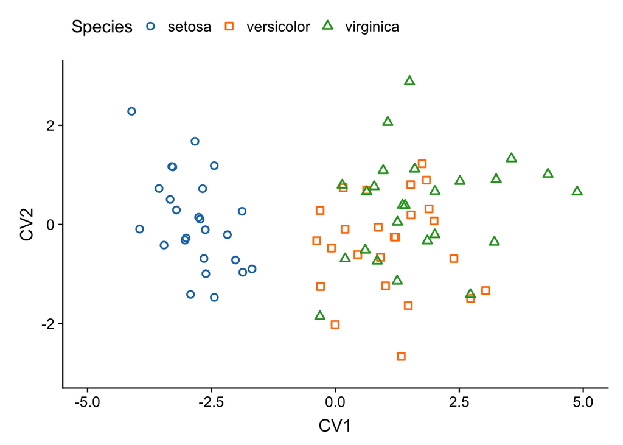

```r
plot_CV <-
  ggplot() +
  draw_grouped_points(CV.scores, CV1, CV2, Species, position = fixed.jitter) +
  labs(x = "CV1", y = "CV2") +
  xlim(-5,5) + ylim(-3,3) +
  coord_fixed() +
  plot.theme

plot_CV
```

# Reversing the transformation

What we’ve done above is walk through a series of transformations, that include a rigid rotation (to the within group PCs), a scaling, and a second rigid rotation.

## CVs to scaled PC space

```r
# since eigenvectors are orthonormal, A^t = A-1 (transpose is inverse)

CV.scores.in.scaled.mtx <-
  CV.scores.mtx %*% t(group.eigen$vectors) %>%
  set_colnames(c("scaledPC1","scaledPC2"))

CV.scores.in.scaled <-
  CV.scores.in.scaled.mtx %>%
  as.data.frame %>%
  mutate(Species = iris.sepals$Species)

CV.axes <- matrix(c(1,0,0,1),nrow=2)
CV.axes.in.scaled.mtx <-
  CV.axes %*% t(group.eigen$vectors) %>%
  set_colnames(c("CV1", "CV2"))

CV.axes.in.scaled <-
  CV.axes.in.scaled.mtx %>%
  as.data.frame
```

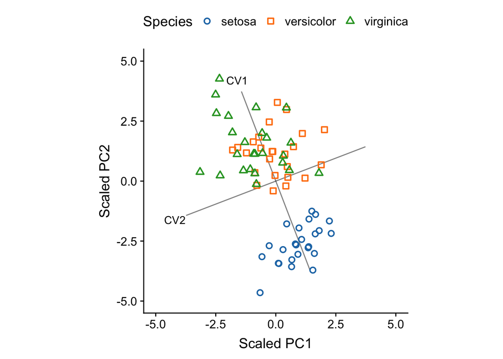

```r
plot_CV.back1 <-
  ggplot() +
  draw_axes(CV.axes.in.scaled, 4 * CV1, 4 * CV2, alpha = 0.5) +
  label_axes(CV.axes.in.scaled, 4.5 * CV1, 4.5 * CV2, label = c("CV1","CV2")) +
  draw_grouped_points(CV.scores.in.scaled, scaledPC1, scaledPC2, Species,
                      position = fixed.jitter) +
  labs(x = "Scaled PC1", y = "Scaled PC2") +
  xlim(-5,5) + ylim(-5,5) +
  coord_fixed() +
  plot.theme

plot_CV.back1
```

## CVs to unscaled PC space

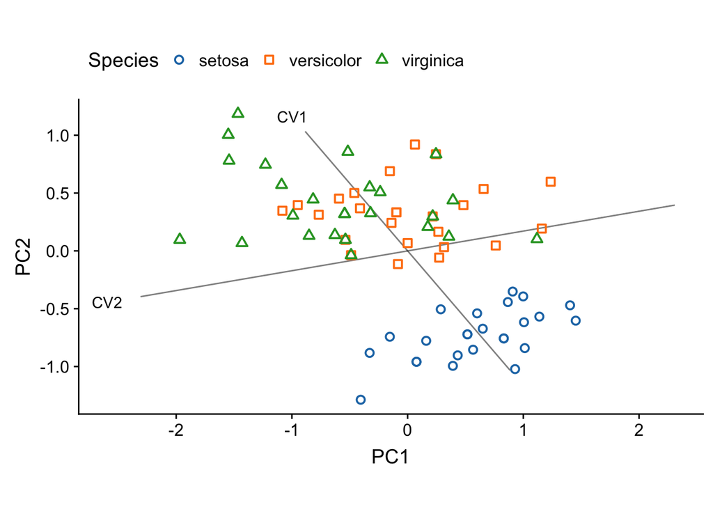

```r
CV.scores.unscaled.mtx <-
  CV.scores.in.scaled.mtx %*% diag(sqrt(win.eigen$values)) %>%
  set_colnames(c("PC1","PC2"))

CV.scores.unscaled <-
  CV.scores.unscaled.mtx %>%
  as.data.frame %>%
  mutate(Species = iris.sepals$Species)

CV.axes.unscaled.mtx <-
  CV.axes.in.scaled.mtx %*% diag(sqrt(win.eigen$values)) %>%
  set_colnames(c("CV1", "CV2"))

CV.axes.unscaled <-
  CV.axes.unscaled.mtx %>%
  as.data.frame

plot_CV.back2 <-
  ggplot() +
  draw_axes(CV.axes.unscaled, 4 * CV1, 4 * CV2, alpha=0.5) +
  label_axes(CV.axes.unscaled, 4.5 * CV1, 4.5 * CV2, label = c("CV1","CV2")) +
  draw_grouped_points(CV.scores.unscaled, PC1, PC2, Species) +
  labs(x = "PC1", y = "PC2") +
  coord_fixed() +
  theme(legend.position = "top")

plot_CV.back2
```

## Unscaled PC space to original space

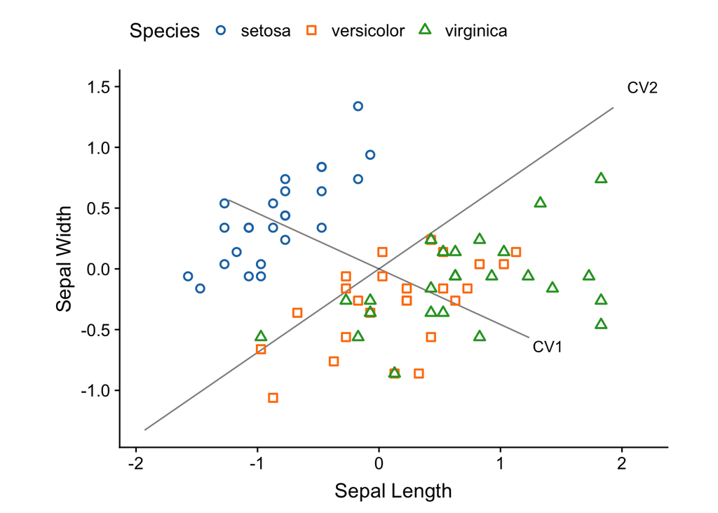

```r
CV.scores.orig.mtx <-
  CV.scores.unscaled.mtx %*% t(win.eigen$vectors) %>%
  set_colnames(c("Sepal.Length", "Sepal.Width"))

CV.scores.orig <-
  as.data.frame(CV.scores.orig.mtx) %>%
  mutate(Species = iris.sepals$Species)

CV.axes.orig.mtx <-
  CV.axes.unscaled.mtx %*% t(win.eigen$vectors) %>%
  set_colnames(c("CV1", "CV2"))

CV.axes.orig <-
  as.data.frame(CV.axes.orig.mtx)

plot_CV.back3 <-
  ggplot() +
  draw_axes(CV.axes.orig, 4 * CV1, 4 * CV2, alpha=0.5) +
  label_axes(CV.axes.orig, 4.5 * CV1, 4.5 * CV2, label = c("CV1","CV2")) +
  draw_grouped_points(CV.scores.orig, Sepal.Length, Sepal.Width, Species) +
  labs(x = "Sepal Length", y = "Sepal Width") +
  coord_fixed() +
  theme(legend.position = "top")

plot_CV.back3
```

# CVA without the intermediate steps

```r
# Cacluate the  eigenvectors of W^{-1}B
WinvB = solve(cov.win) %*% cov.btw
eigin.WinvB = eigen(WinvB)

cva.vecs <- Re(eigin.WinvB$vectors)[,1:ngroups-1]
cva.vals <- Re(eigin.WinvB$values)[1:ngroups-1]

unscaled.scores <- win.deviates %*% cva.vecs

# figure out scaling so group covariance matrix is spherical
scaling <- diag(1/sqrt((t(unscaled.scores) %*% unscaled.scores)/(nobs-ngroups)))

# compare to "scaling" component object returned by lda()
scaled.cva.vecs <- cva.vecs %*% diag(scaling)

cva.scores <- iris.sepals.mtx %*% scaled.cva.vecs

colnames(cva.scores) <- c("CV1","CV2")
cva.scores <- as.data.frame(cva.scores)
cva.scores$Species <- iris.sepals$Species
```

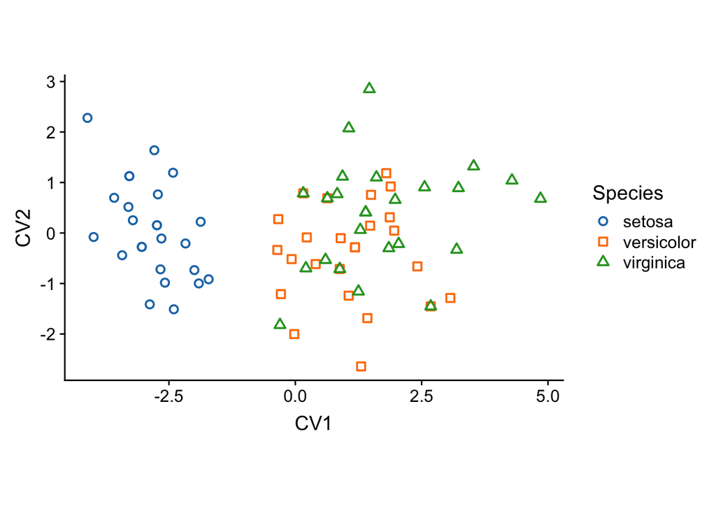

```r
ggplot(cva.scores, aes(x = CV1, y = CV2)) +
  geom_point(aes(color=Species, shape=Species)) +
  coord_fixed()
```